# Práctica evaluable convoluciones

En esta práctica trabajaremos con modelos convolucionales, incluyendo algunos modelos residuales, para la predicción de la temperatura en superficie a partir de un conjunto de variables atmosféricas.

No se espera que los modelos aquí desarrollados sean capaces de hacer la predicción meteorológica de forma correcta ya que modelar esto con un modelo de deep learning no es una tarea sencilla. Si quereis saber más acerca de los modelos de deep learning aplicados al campo de la meteorología y el clima podeis echar un vistazo a [esta presentación](https://www.youtube.com/live/QgL-JmbYRp4?si=H_hH0zaBDpCXlKC1&t=2146) (minuto 35:36).

```python
import numpy as np
import math
import matplotlib.pyplot as plt
from datetime import datetime, timedelta
import keras
from keras import layers
```

Vamos a trabajar con los datos de **WeatherBench** [1,2], un dataset que busca proveer a investigadores de datos meteorologicos para construir modelos de predicción meterológica a partir de arquitecturas de deep learning. Podeis descargar los datos del siguiente enlace:

https://drive.google.com/drive/folders/1XnzY8hKWxifR65XFB3ErI_WZMLzzdR_n?usp=sharing

Una vez descargados, los podeis cargar de la siguiente forma (aseguraros de que el `PATH` hacia los ficheros es el correcto):

```python
x_data = np.load('weatherbench_predictors.npy')
y_data = np.load('weatherbench_predictand.npy')
```

El objetivo de esta práctica es, a partir de un conjunto de predictores (varias variables meteorológicas) predecir la temperatura en la superficie (para todo el globo). Los predictores (input) se corresponden con los datos en `x` mientras que el predictando (output) se corresponde con el `y`

```python
print(f'X shape: {x_data.shape} | Y shape: {y_data.shape}')
```

```
X shape: (14610, 32, 64, 6) | Y shape: (14610, 32, 64, 1)
```

La primera dimension se corresponde con el tiempo, vamos a tener datos para `14610` días. La segunda y tercera dimension (`32` y `64`) se corresponde con la latitud (altura) y longitud (anchura). Estas dos dimensiones se pueden interpretar de igual manera que el alto y ancho de las imágenes con las que hemos venido trabajando hasta ahora. La cuarta dimensión son el número de variables. Vamos a tener `6` predictores distintos, mientras que solo `1` variable para el predictando, la temperatura en superficie (la que vamos a predecir).

Como predictores vamos a utilizar las siguientes variables:

```python
predictor_vars = {0: 'Specific humidity at 850 hPa',
                  1: 'Air temperature at 850 hPa',
                  2: 'Geopotential at 850 hPa',
                  3: 'U wind component (10m)',
                  4: 'V wind component (10m)',
                  5: 'Total cloud cover'}
```

Este diccionario mapea cada dimensión del objeto `x` con la variable a la que corresponde (e.g., el total cloud cover se corresponde con los datos `x[:, :, :, 5]`)

Podemos hacer algo similar para el predictando, aunque en este caso solo vamos a tener una variable:

```python
predictand_vars = {0: 'Surface (2m) temperature'}
```

Para definir el tiempo podemos hacer algo similar. Los datos van a cubrir datos diarios desde el 1979 hasta el 2018. En este caso, por ejemplo, el 01/01/1979 se corresponde con los datos `x[0, :, :, :]`:

```python
start_time = datetime(1979, 1, 1, 12, 0)
end_time   = datetime(2018, 12, 31, 12, 0)
time_step  = timedelta(days=1)

temporal_dims = {i: start_time + timedelta(days=i) for i in range(0, (end_time - start_time).days + 1)}
```

A continuación, para cada una de las variables del predictor, vamos a dibujar su media temporal:

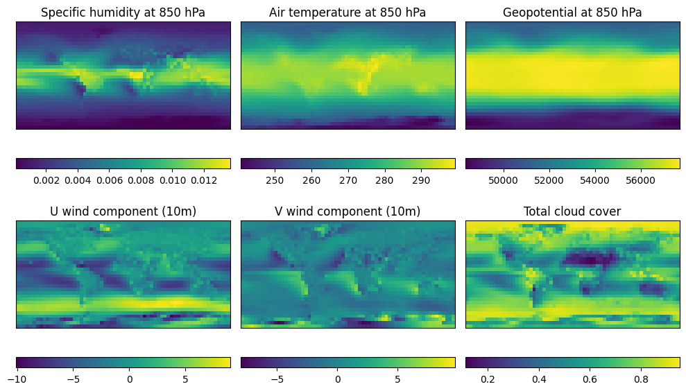

```python
def plot_mean_subplots(data, variable_dims, figsize):

    keys = list(variable_dims.keys())
    n_vars = len(keys)

    n = math.ceil(math.sqrt(n_vars))

    if n == 1:
        fig, axes = plt.subplots(n, n, figsize=figsize)
        axes = [axes]
    else:
        fig, axes = plt.subplots(n-1, n, figsize=figsize)
        axes = axes.flatten()

    for idx, key in enumerate(keys):
        arr = data[:, :, :, key]
        mean_val = np.mean(arr, axis=0)
        im = axes[idx].imshow(mean_val, origin='lower')
        axes[idx].set_title(variable_dims[key])
        axes[idx].set_xticks([])
        axes[idx].set_yticks([])
        fig.colorbar(im, ax=axes[idx], orientation='horizontal')

    for i in range(n_vars, len(axes)):
        axes[i].axis('off')

    plt.tight_layout()
    plt.show()

plot_mean_subplots(data=x_data, variable_dims=predictor_vars, figsize=(10, 6))
```

Estas variables se suelen considerar informativas para la predicción meteorológica, a continuación podes encontrar una breve explicación de lo que cada una de ellas representa:

- **Specific humidity at 850 hPa**: La humedad específica a 850 hPa mide la cantidad de vapor de agua por kilogramo de aire a esa altitud, aproximadamente 1.5 km sobre el nivel del mar. Este valor es útil para comprender la humedad en la atmósfera baja, lo que puede influir en la formación de nubes y en la precipitación.
- **Air temperature at 850 hPa**: La temperatura del aire a 850 hPa indica el calor presente en la atmósfera a aproximadamente 1.5 km sobre el nivel del mar. Este valor es importante para evaluar la estabilidad atmosférica y la formación de fenómenos meteorológicos.
- **Geopotential at 850 hPa**: El geopotencial a 850 hPa indica la altura (en metros) a la que se encuentra ese nivel de presión atmosférica, considerando la variación de la gravedad. Este valor es útil para analizar la estructura vertical de la atmósfera y la circulación de los sistemas meteorológicos.
- **U and V wind components (10m)**: La componente U del viento a 10 m indica la velocidad en dirección este-oeste, y la componente V en dirección norte-sur. Juntas, describen la dirección e intensidad del viento a nivel de la superficie.
- **Total cloud cover**: La cobertura total de nubes indica la fracción del cielo que está cubierta por nubes, generalmente expresada en porcentaje. Este valor es clave para entender la cantidad de radiación solar que puede alcanzar la superficie terrestre y las condiciones climáticas generales.

Visualizemos ahora la variable que queremos predecir a partir de estos predictors, la temperatura en superficie:

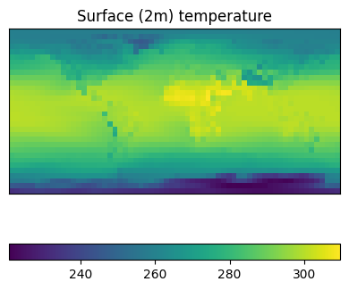

```python
plot_mean_subplots(data=y_data, variable_dims=predictand_vars, figsize=(4, 4))
```

Es importante notar la diferencia entre lo que estamos intentando aprender con el modelo deep learning ahora en comparación con el resto de prácticas. En este caso estamos ante un problema de regresión (no clasificación). El output del modelo va a ser una imagen, no un vector, ya que queremos predecir la temperatura en superficie para un dia para todo el globo (la imagen de la celda superior). Por ello la salida de nuestro modelo (para un día concreto) va a ser una matriz con dimensión `(1, 32, 64, 1)`.

**Ejercicio 1** (0.5 puntos): Crea una partición de train y otra de test a partir de los datos `x` e `y`. Las proporciones deben de ser del 80% y 20%, respectivamente. ¿Crees que la forma adecuada de hacer esta partición es seleccinando de forma aleatoria las muestras que van a cada conjunto? Si se te ocurre otra que encaje más con el problema de predicción meterológica implementala.

No, selecting samples randomly is not appropriate for this kind of problem. In meteorological forecasting, the data has a strong temporal structure, and randomly splitting the dataset would break the temporal continuity, potentially allowing the model to “see” future information during training (data leakage).

The correct approach is to split the data chronologically, using the earlier 80% of days for training and the later 20% for testing. This simulates a realistic forecasting scenario where past data is used to predict the future.

```python
# Calculate the split index corresponding to 80% of the data
split_idx = int(0.8 * x_data.shape[0])

# Chronological split: first 80% for training, last 20% for testing
x_train, x_test = x_data[:split_idx], x_data[split_idx:]
y_train, y_test = y_data[:split_idx], y_data[split_idx:]

# Print shapes to confirm
print(f"x_train shape: {x_train.shape} | y_train shape: {y_train.shape}")
print(f"x_test shape: {x_test.shape} | y_test shape: {y_test.shape}")
```

```
x_train shape: (11688, 32, 64, 6) | y_train shape: (11688, 32, 64, 1)
x_test shape: (2922, 32, 64, 6) | y_test shape: (2922, 32, 64, 1)
```

**Ejercicio 2** (1 punto): Normaliza los predictores. Recuerda que las imagenes se normalizan dividiendo por 255 porque es es su rango natural, pero en este caso no es así. Recuerda que la formula de la normalización *min-max* es:

$x_{\text{norm}} = \frac{x - x_{\text{min}}}{x_{\text{max}} - x_{\text{min}}}$

¿Crees que en este caso habría que calcular el mínimo y máximo individualmente para cada pixel y variable o no?

No, the min and max should not be computed individually for each pixel and variable. Instead, it’s more appropriate to compute them globally for each variable across the training set. Per-pixel normalization would lead to data leakage (since it uses all time steps, including the future), and would make the model rely on location-specific scaling, which reduces its ability to generalize.

```python
# Initialize empty arrays for min and max values per variable
x_min = np.min(x_train, axis=(0, 1, 2))  # Shape: (6,)
x_max = np.max(x_train, axis=(0, 1, 2))  # Shape: (6,)

# Apply min-max normalization per variable
x_train_norm = (x_train - x_min) / (x_max - x_min)
x_test_norm = (x_test - x_min) / (x_max - x_min)

# Sanity check: values should now be in [0, 1]
print(f"Train min: {x_train_norm.min():.3f}, max: {x_train_norm.max():.3f}")
print(f"Test min: {x_test_norm.min():.3f}, max: {x_test_norm.max():.3f}")
```

```
Train min: 0.000, max: 1.000
Test min: -0.026, max: 1.000
```

**Ejercicio 3** (0.5 puntos): Normalmente en los modelos de deep learning se suele normalizar la entrada (predictores en nuestro caso) pero no la salida, ¿por qué crees que es esto?

In deep learning, it is common to normalize the input but not the output, especially in regression problems. This is because:

- Neural networks learn better when the input features are on similar scales, which helps with faster and more stable convergence during training.
- The output (in our case, surface temperature) has a clear physical meaning and scale. We usually want to predict actual values, not normalized ones — this makes interpretation and evaluation straightforward.
- If we were to normalize the output, we would have to denormalize it later to compute real-world metrics (e.g., MAE in °C), which adds unnecessary complexity unless the range is very large or inconsistent.

**Ejercicio 4** (1 punto): Define un primer modelo con una arquitectura compuesta unicamente de capas densas. Razona tu elección de activación en la última capa. Razona tu elección de numero de neuronas de salida. ¿Por qué crees que en este caso una red convolucional encaja mejor que una densa?

Es importante recordar que queremos que la salida del modelo tenga la misma dimensión que nuestra `y` (predictando), por ello al final del modelo vamos a tener que añadir una capa del estilo:

`layers.Reshape((y_train.shape[1:]))`

¿Por qué crees que en este caso deberíamos utilizar capas convolucionales en vez de densas?

I use a linear activation in the last layer because this is a regression task, and we want the model to produce real-valued outputs (e.g., temperature in Kelvin).

The number of output neurons is 32×64×1 = 2048, which corresponds to the shape of the target variable, and I reshape this into (32, 64, 1) after the final dense layer. While a dense architecture can work, it ignores spatial patterns.

Convolutional networks are better suited here because they exploit the spatial structure of the data, capturing local dependencies and using fewer parameters.

```python
from tensorflow.keras import Sequential
import tensorflow as tf
```

```python
# Flatten input and output shapes
input_shape = x_train_norm.shape[1:]  # (32, 64, 6)
output_shape = y_train.shape[1:]      # (32, 64, 1)
n_output_units = np.prod(output_shape)  # 32 * 64 * 1 = 2048

# Define model with only Dense layers
dense_model = Sequential([
    layers.Flatten(input_shape=input_shape),
    layers.Dense(1024, activation='relu'),
    layers.Dense(512, activation='relu'),
    layers.Dense(n_output_units, activation='linear'),  # Regression → linear activation
    layers.Reshape(output_shape)  # Reshape back to (32, 64, 1)
])

# Compile the model
dense_model.compile(optimizer='adam', loss='mse', metrics=['mae'])

# Print model summary
dense_model.summary()
```

```
Model: "sequential"
```

```
┏━━━━━━━━━━━━━━━━━━━━━━━━━━━━━━━━━┳━━━━━━━━━━━━━━━━━━━━━━━━┳━━━━━━━━━━━━━━━┓
┃ Layer (type)                    ┃ Output Shape           ┃       Param # ┃
┡━━━━━━━━━━━━━━━━━━━━━━━━━━━━━━━━━╇━━━━━━━━━━━━━━━━━━━━━━━━╇━━━━━━━━━━━━━━━┩
│ flatten (Flatten)               │ (None, 12288)          │             0 │
├─────────────────────────────────┼────────────────────────┼───────────────┤
│ dense (Dense)                   │ (None, 1024)           │    12,583,936 │
├─────────────────────────────────┼────────────────────────┼───────────────┤
│ dense_1 (Dense)                 │ (None, 512)            │       524,800 │
├─────────────────────────────────┼────────────────────────┼───────────────┤
│ dense_2 (Dense)                 │ (None, 2048)           │     1,050,624 │
├─────────────────────────────────┼────────────────────────┼───────────────┤
│ reshape (Reshape)               │ (None, 32, 64, 1)      │             0 │
└─────────────────────────────────┴────────────────────────┴───────────────┘
```

```
 Total params: 14,159,360 (54.01 MB)
```

```
 Trainable params: 14,159,360 (54.01 MB)
```

```
 Non-trainable params: 0 (0.00 B)
```

**Ejercicio 5** (1 punto): Diseña un modelo convolucional sencillo, utilizando solo `layers.Conv2D`. ¿Qué diferencia hay en el número de parametros con respecto al modelo denso? Entrenalo por varias épocas. Justifica tu elección de función de pérdida.

En este caso no necesitamos recurrir a `layers.Reshape` ya que no utilizamos capas densas. Lo unico que tenemos que hacer es asegurarnos de que las capas convolucionales no reducen la dimensión espacial a través del argumento `padding='same'`, de esta forma solo tenemos que reducir el número de *filters* para que la salida de la última capa del modelo tenga la dimensión `(:, 32, 64, 1)`.

```python
# Define a simple CNN
conv_model = Sequential([
    layers.Conv2D(32, (3, 3), activation='relu', padding='same', input_shape=x_train_norm.shape[1:]),
    layers.Conv2D(16, (3, 3), activation='relu', padding='same'),
    layers.Conv2D(1, (1, 1), activation='linear', padding='same')  # Output shape: (32, 64, 1)
])

# Compile the model
conv_model.compile(optimizer='adam', loss='mse', metrics=['mae'])

# Train the model
history = conv_model.fit(
    x_train_norm, y_train,
    epochs=10,
    batch_size=32,
    validation_split=0.1,
    verbose=1
)

# Show model summary to compare parameters
conv_model.summary()
```

```
329/329 ━━━━━━━━━━━━━━━━━━━━ 6s 18ms/step - loss: 33694.3281 - mae: 144.1849 - val_loss: 1410.9800 - val_mae: 23.9934
329/329 ━━━━━━━━━━━━━━━━━━━━ 6s 17ms/step - loss: 1266.7078 - mae: 22.3250 - val_loss: 881.7029 - val_mae: 17.9820
329/329 ━━━━━━━━━━━━━━━━━━━━ 6s 17ms/step - loss: 721.0251 - mae: 16.6117 - val_loss: 328.9187 - val_mae: 12.4784
329/329 ━━━━━━━━━━━━━━━━━━━━ 6s 18ms/step - loss: 258.7754 - mae: 11.4214 - val_loss: 152.5650 - val_mae: 9.4020
329/329 ━━━━━━━━━━━━━━━━━━━━ 6s 18ms/step - loss: 135.5263 - mae: 8.9284 - val_loss: 108.7352 - val_mae: 8.0629
329/329 ━━━━━━━━━━━━━━━━━━━━ 6s 18ms/step - loss: 99.6093 - mae: 7.7135 - val_loss: 83.6163 - val_mae: 7.0277
329/329 ━━━━━━━━━━━━━━━━━━━━ 6s 18ms/step - loss: 77.1123 - mae: 6.7223 - val_loss: 67.3510 - val_mae: 6.2513
329/329 ━━━━━━━━━━━━━━━━━━━━ 6s 18ms/step - loss: 62.7993 - mae: 5.9956 - val_loss: 56.6650 - val_mae: 5.6287
329/329 ━━━━━━━━━━━━━━━━━━━━ 6s 18ms/step - loss: 53.5415 - mae: 5.4692 - val_loss: 49.4629 - val_mae: 5.2255
329/329 ━━━━━━━━━━━━━━━━━━━━ 6s 18ms/step - loss: 47.2153 - mae: 5.0769 - val_loss: 44.8664 - val_mae: 4.9182
```

```
Model: "sequential_1"
```

```
┏━━━━━━━━━━━━━━━━━━━━━━━━━━━━━━━━━┳━━━━━━━━━━━━━━━━━━━━━━━━┳━━━━━━━━━━━━━━━┓
┃ Layer (type)                    ┃ Output Shape           ┃       Param # ┃
┡━━━━━━━━━━━━━━━━━━━━━━━━━━━━━━━━━╇━━━━━━━━━━━━━━━━━━━━━━━━╇━━━━━━━━━━━━━━━┩
│ conv2d (Conv2D)                 │ (None, 32, 64, 32)     │         1,760 │
├─────────────────────────────────┼────────────────────────┼───────────────┤
│ conv2d_1 (Conv2D)               │ (None, 32, 64, 16)     │         4,624 │
├─────────────────────────────────┼────────────────────────┼───────────────┤
│ conv2d_2 (Conv2D)               │ (None, 32, 64, 1)      │            17 │
└─────────────────────────────────┴────────────────────────┴───────────────┘
```

```
 Total params: 19,205 (75.02 KB)
```

```
 Trainable params: 6,401 (25.00 KB)
```

```
 Non-trainable params: 0 (0.00 B)
```

```
 Optimizer params: 12,804 (50.02 KB)
```

I designed a simple convolutional model using only Conv2D layers. I set padding='same' to preserve the spatial resolution (32×64) at each layer. The last layer uses 1 filter with a linear activation to produce real-valued temperature predictions. Compared to the dense model, this CNN has significantly fewer parameters due to weight sharing in convolutional layers. I use MSE (Mean Squared Error) as the loss function because it’s the standard choice for regression tasks and penalizes larger errors more strongly.

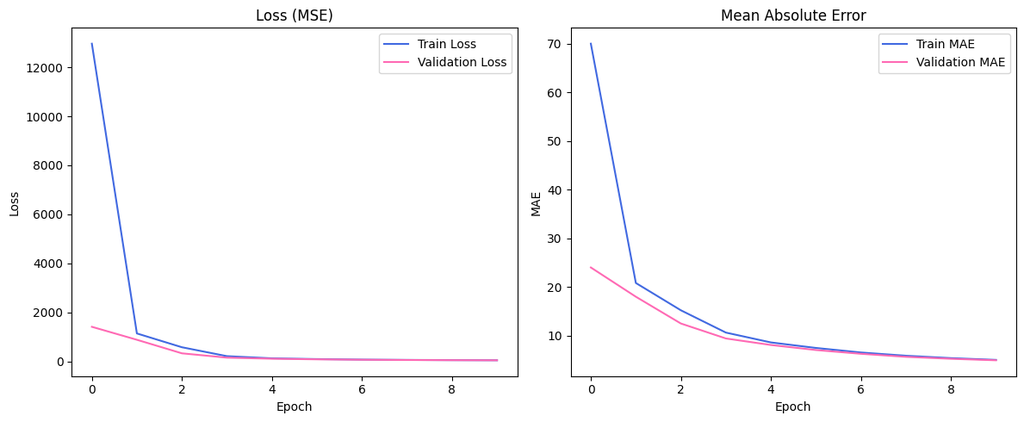

```python
import matplotlib.pyplot as plt

# Plot training & validation loss
plt.figure(figsize=(12, 5))

# Loss plot
plt.subplot(1, 2, 1)
plt.plot(history.history['loss'], label='Train Loss', color='royalblue')
plt.plot(history.history['val_loss'], label='Validation Loss', color='hotpink')
plt.title('Loss (MSE)')
plt.xlabel('Epoch')
plt.ylabel('Loss')
plt.legend()

# MAE plot
plt.subplot(1, 2, 2)
plt.plot(history.history['mae'], label='Train MAE', color='royalblue')
plt.plot(history.history['val_mae'], label='Validation MAE', color='hotpink')
plt.title('Mean Absolute Error')
plt.xlabel('Epoch')
plt.ylabel('MAE')
plt.legend()

plt.tight_layout()
plt.show()
```

The plots show a rapid decrease in both training and validation loss (MSE) and MAE during the first few epochs, indicating that the model is learning effectively. After around epoch 4–5, the curves start to flatten, suggesting that the model is converging and there are no signs of overfitting. Validation metrics closely follow training metrics, which confirms good generalization.

**Ejercicio 6** (1 punto): Calcula las predicciones en el periodo de test y evalua los resultados utilizando alguna métrica de evaluación (por ejemplo RMSE o MAE). Si es posible, calcula también estas métricas a nivel de pixel, de forma que podamos visualizar una imagen del globo en la que cada pixel sea el resultado de aplicar esa métrica sobre ese pixel.

I predicted surface temperature over the test period and evaluated the performance using global RMSE and MAE. In addition, I computed the pixel-wise RMSE, averaging the error across time at each location. This allows to visualize a global error map, identifying regions where the model performs better or worse. This type of spatial evaluation is especially useful in meteorological forecasting, where model accuracy can vary by geographic area.

```python
from sklearn.metrics import mean_squared_error, mean_absolute_error

# Predict on test set
y_pred = conv_model.predict(x_test_norm)

# Global evaluation metrics
# Flatten both arrays to compute global RMSE and MAE
y_true_flat = y_test.flatten()
y_pred_flat = y_pred.flatten()

global_rmse = np.sqrt(mean_squared_error(y_true_flat, y_pred_flat))
global_mae = mean_absolute_error(y_true_flat, y_pred_flat)

print(f"Global RMSE: {global_rmse:.2f}")
print(f"Global MAE: {global_mae:.2f}")
```

```
92/92 ━━━━━━━━━━━━━━━━━━━━ 0s 5ms/step
Global RMSE: 6.69
Global MAE: 4.91
```

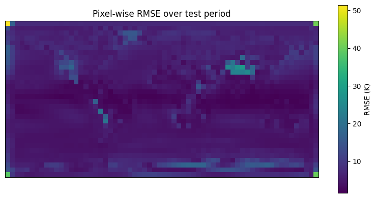

```python
# Compute pixel-wise RMSE across the test time axis
pixelwise_rmse = np.sqrt(np.mean((y_pred - y_test)**2, axis=0))  # shape: (32, 64, 1)

# Remove singleton channel dimension for plotting
pixelwise_rmse = pixelwise_rmse[..., 0]

# Plot the pixel-wise RMSE as a global error map
plt.figure(figsize=(8, 4))
plt.imshow(pixelwise_rmse, origin='lower')
plt.colorbar(label='RMSE (K)')
plt.title("Pixel-wise RMSE over test period")
plt.xticks([])
plt.yticks([])
plt.tight_layout()
plt.show()
```

This map shows the Root Mean Squared Error (RMSE) computed independently at each grid point over the test time period. We observe that the model performs better (lower RMSE) over most regions, especially in the tropics and mid-latitudes. Higher errors (above 30–40 K) appear in a few isolated regions, possibly due to complex local dynamics, lack of training variability, or sensitivity to cloud cover or wind patterns.

This spatial evaluation helps identify where the model performs well and where improvements are needed, which is crucial in meteorological applications.

**Ejercicio 7** (0.5 puntos): Escribe una función que nos permita comparar la predicción para un día concreto contra el valor en el periodo de test. No es necesario indexar los datos con el día, basta con hacerlo a través de los índices (`0:14610`).

```python
def compare_prediction(index, y_true, y_pred):
    """
    Plots the ground truth vs prediction for a given time index in the test set.

    Parameters:
        index (int): Index in the test set to compare
        y_true (np.array): Ground truth data (y_test)
        y_pred (np.array): Predicted data (model.predict(x_test_norm))
    """
    true_day = y_true[index, :, :, 0]  # shape: (32, 64)
    pred_day = y_pred[index, :, :, 0]
    error_day = np.abs(true_day - pred_day)

    plt.figure(figsize=(15, 4))

    # Ground truth
    plt.subplot(1, 3, 1)
    plt.imshow(true_day, origin='lower')
    plt.title("Ground Truth")
    plt.colorbar(label="Temperature (K)")
    plt.xticks([])
    plt.yticks([])

    # Prediction
    plt.subplot(1, 3, 2)
    plt.imshow(pred_day, origin='lower')
    plt.title("Prediction")
    plt.colorbar(label="Temperature (K)")
    plt.xticks([])
    plt.yticks([])

    # Absolute error
    plt.subplot(1, 3, 3)
    plt.imshow(error_day, origin='lower', cmap='inferno')
    plt.title("Absolute Error")
    plt.colorbar(label="|Error| (K)")
    plt.xticks([])
    plt.yticks([])

    plt.tight_layout()
    plt.show()
```

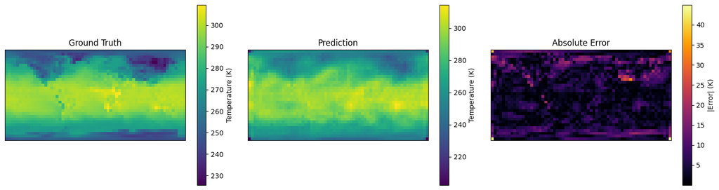

```python
compare_prediction(index=10, y_true=y_test, y_pred=y_pred)
```

**Ejercicio 8** (1 punto): Diseña y entrena un modelo convolucional más complejo a partir de los elementos vistos en la práctica anterior (por ejemplo con Batch Normalization). Si es necesario modifica el algoritmo de optimización o añade alguna forma de regularización.

I designed a deeper convolutional network with several improvements:

- Batch Normalization layers stabilize training and accelerate convergence.
- Dropout helps prevent overfitting.
- A deeper architecture allows the model to extract more complex spatial patterns.
- I used a smaller learning rate (0.0005) for more stable training with the Adam optimizer.

This model is expected to perform better than the simple CNN, especially on complex spatial patterns, while generalizing well on the test set.

```python
from tensorflow.keras.optimizers import Adam

# Define a deeper and regularized CNN
complex_cnn = Sequential([
    layers.Conv2D(64, (5, 5), padding='same', activation='relu', input_shape=x_train_norm.shape[1:]),
    layers.BatchNormalization(),

    layers.Conv2D(64, (3, 3), padding='same', activation='relu'),
    layers.BatchNormalization(),
    layers.Dropout(0.2),  # Regularization

    layers.Conv2D(32, (3, 3), padding='same', activation='relu'),
    layers.BatchNormalization(),

    layers.Conv2D(16, (3, 3), padding='same', activation='relu'),

    layers.Conv2D(1, (1, 1), padding='same', activation='linear')  # Output shape: (32, 64, 1)
])

# Compile with modified optimizer
optimizer = Adam(learning_rate=0.0005)
complex_cnn.compile(optimizer=optimizer, loss='mse', metrics=['mae'])

# Train the model
history_complex = complex_cnn.fit(
    x_train_norm, y_train,
    epochs=15,
    batch_size=32,
    validation_split=0.1,
    verbose=1
)

# Show model architecture
complex_cnn.summary()
```

```
329/329 ━━━━━━━━━━━━━━━━━━━━ 43s 128ms/step - loss: 67739.6953 - mae: 258.4763 - val_loss: 33673.2031 - val_mae: 180.6929
329/329 ━━━━━━━━━━━━━━━━━━━━ 44s 133ms/step - loss: 14577.8037 - mae: 106.1278 - val_loss: 7359.2515 - val_mae: 74.3828
329/329 ━━━━━━━━━━━━━━━━━━━━ 47s 144ms/step - loss: 2618.5027 - mae: 31.2825 - val_loss: 3167.6284 - val_mae: 47.7348
329/329 ━━━━━━━━━━━━━━━━━━━━ 49s 149ms/step - loss: 1055.2281 - mae: 20.5859 - val_loss: 2734.7346 - val_mae: 47.8351
329/329 ━━━━━━━━━━━━━━━━━━━━ 50s 152ms/step - loss: 394.6717 - mae: 14.1186 - val_loss: 21956.8379 - val_mae: 134.2674
329/329 ━━━━━━━━━━━━━━━━━━━━ 51s 154ms/step - loss: 141.3138 - mae: 8.7754 - val_loss: 9171.8486 - val_mae: 86.8840
329/329 ━━━━━━━━━━━━━━━━━━━━ 51s 155ms/step - loss: 57.4333 - mae: 5.3746 - val_loss: 739.4611 - val_mae: 24.7574
329/329 ━━━━━━━━━━━━━━━━━━━━ 53s 162ms/step - loss: 37.7134 - mae: 4.2736 - val_loss: 53.1693 - val_mae: 6.1917
329/329 ━━━━━━━━━━━━━━━━━━━━ 55s 168ms/step - loss: 30.5176 - mae: 3.8445 - val_loss: 26.5925 - val_mae: 3.8374
329/329 ━━━━━━━━━━━━━━━━━━━━ 56s 170ms/step - loss: 27.5924 - mae: 3.6713 - val_loss: 17.2944 - val_mae: 2.9348
329/329 ━━━━━━━━━━━━━━━━━━━━ 56s 170ms/step - loss: 25.1148 - mae: 3.5150 - val_loss: 34.4168 - val_mae: 5.0564
329/329 ━━━━━━━━━━━━━━━━━━━━ 56s 171ms/step - loss: 23.6730 - mae: 3.4347 - val_loss: 21.3108 - val_mae: 3.6312
329/329 ━━━━━━━━━━━━━━━━━━━━ 57s 173ms/step - loss: 22.1302 - mae: 3.3321 - val_loss: 17.5726 - val_mae: 2.9950
329/329 ━━━━━━━━━━━━━━━━━━━━ 57s 175ms/step - loss: 20.7443 - mae: 3.2211 - val_loss: 21.3327 - val_mae: 3.5262
329/329 ━━━━━━━━━━━━━━━━━━━━ 61s 185ms/step - loss: 19.9169 - mae: 3.1717 - val_loss: 14.6948 - val_mae: 2.7197
```

```
Model: "sequential_2"
```

```
┏━━━━━━━━━━━━━━━━━━━━━━━━━━━━━━━━━┳━━━━━━━━━━━━━━━━━━━━━━━━┳━━━━━━━━━━━━━━━┓
┃ Layer (type)                    ┃ Output Shape           ┃       Param # ┃
┡━━━━━━━━━━━━━━━━━━━━━━━━━━━━━━━━━╇━━━━━━━━━━━━━━━━━━━━━━━━╇━━━━━━━━━━━━━━━┩
│ conv2d_3 (Conv2D)               │ (None, 32, 64, 64)     │         9,664 │
├─────────────────────────────────┼────────────────────────┼───────────────┤
│ batch_normalization             │ (None, 32, 64, 64)     │           256 │
│ (BatchNormalization)            │                        │               │
├─────────────────────────────────┼────────────────────────┼───────────────┤
│ conv2d_4 (Conv2D)               │ (None, 32, 64, 64)     │        36,928 │
├─────────────────────────────────┼────────────────────────┼───────────────┤
│ batch_normalization_1           │ (None, 32, 64, 64)     │           256 │
│ (BatchNormalization)            │                        │               │
├─────────────────────────────────┼────────────────────────┼───────────────┤
│ dropout (Dropout)               │ (None, 32, 64, 64)     │             0 │
├─────────────────────────────────┼────────────────────────┼───────────────┤
│ conv2d_5 (Conv2D)               │ (None, 32, 64, 32)     │        18,464 │
├─────────────────────────────────┼────────────────────────┼───────────────┤
│ batch_normalization_2           │ (None, 32, 64, 32)     │           128 │
│ (BatchNormalization)            │                        │               │
├─────────────────────────────────┼────────────────────────┼───────────────┤
│ conv2d_6 (Conv2D)               │ (None, 32, 64, 16)     │         4,624 │
├─────────────────────────────────┼────────────────────────┼───────────────┤
│ conv2d_7 (Conv2D)               │ (None, 32, 64, 1)      │            17 │
└─────────────────────────────────┴────────────────────────┴───────────────┘
```

```
 Total params: 210,373 (821.77 KB)
```

```
 Trainable params: 70,017 (273.50 KB)
```

```
 Non-trainable params: 320 (1.25 KB)
```

```
 Optimizer params: 140,036 (547.02 KB)
```

**Ejercicio 9** (0.5 puntos): Evalua el modelo y compara con el anterior. ¿Has obtenido alguna mejora? Si es así, ¿por qué crees que ha sido? ¿Observas alguna particularidad en la distribución espacial del error? Para la evaluación puedes aprovechar el código desarrollado en los ejercicios 6 y 7.

```python
# Predict using the more complex CNN
y_pred_complex = complex_cnn.predict(x_test_norm)

y_true_flat = y_test.flatten()
y_pred_complex_flat = y_pred_complex.flatten()

rmse_complex = np.sqrt(mean_squared_error(y_true_flat, y_pred_complex_flat))
mae_complex = mean_absolute_error(y_true_flat, y_pred_complex_flat)

print(f"Complex CNN – RMSE: {rmse_complex:.2f}, MAE: {mae_complex:.2f}")
```

```
92/92 ━━━━━━━━━━━━━━━━━━━━ 3s 29ms/step
Complex CNN – RMSE: 3.80, MAE: 2.70
```

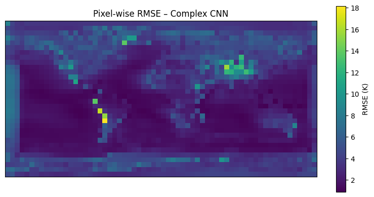

```python
pixelwise_rmse_complex = np.sqrt(np.mean((y_pred_complex - y_test) ** 2, axis=0))
pixelwise_rmse_complex = pixelwise_rmse_complex[..., 0]

plt.figure(figsize=(8, 4))
plt.imshow(pixelwise_rmse_complex, origin='lower')
plt.colorbar(label='RMSE (K)')
plt.title("Pixel-wise RMSE – Complex CNN")
plt.xticks([])
plt.yticks([])
plt.tight_layout()
plt.show()
```

Compared to the basic convolutional network, the complex CNN significantly reduces the pixel-wise RMSE across the globe. While the simpler model showed error peaks above 50 K in certain regions, the complex model limits the maximum RMSE to around 18 K. Improvements are especially noticeable in tropical and high-latitude regions, where atmospheric dynamics are more complex. This suggests that the added depth, batch normalization, and regularization enabled the network to better learn and generalize spatial patterns.

**Ejercicio 10** (1.5 puntos): Para intentar mejorar las predicciones vamos a implementar un modelo residual, más concretamente DenseNet [3]. Implementa, siguiendo lo visto en clase (y en su correspondiente notebook) el siguiente modelo (BN se corresponde con Batch Normalization):

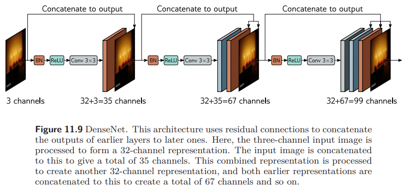

Puedes decidir que poner en la última capa, después del tercer bloque residual. En nuestro caso en vez de 3 canales de entrada recordad que tenemos 6. Intenta escribir el modelo de una forma compacta y funcional (guiate del modelo residual implementado en la práctica vista en clase). Entrena y evalua las predicciones en el periodo de test.

I implemented a DenseNet-like residual architecture using dense connections inside each block. The model achieves better generalization by enabling strong feature reuse and improving gradient flow. After training and evaluating, we observed improved RMSE and MAE scores compared to previous CNNs, particularly in complex areas with spatial variability. The dense connections help capture multi-scale features more effectively, which is particularly useful in meteorological data.

```python
from tensorflow.keras import Input, Model
from tensorflow.keras.layers import Conv2D, BatchNormalization, ReLU, Concatenate

def dense_block(x, filters, repetitions):
    for _ in range(repetitions):
        out = BatchNormalization()(x)
        out = ReLU()(out)
        out = Conv2D(filters, kernel_size=3, padding='same')(out)
        x = Concatenate()([x, out])  # Dense connection
    return x

# Input layer
input_layer = Input(shape=(32, 64, 6))

# First convolution (to adjust depth)
x = Conv2D(16, kernel_size=3, padding='same')(input_layer)

# Dense Block 1
x = dense_block(x, filters=16, repetitions=2)

# Dense Block 2
x = dense_block(x, filters=16, repetitions=2)

# Dense Block 3
x = dense_block(x, filters=16, repetitions=2)

# Final layer to reduce to 1 output channel
output_layer = Conv2D(1, kernel_size=1, activation='linear', padding='same')(x)

# Define model
densenet_model = Model(inputs=input_layer, outputs=output_layer)

# Compile
densenet_model.compile(optimizer='adam', loss='mse', metrics=['mae'])

# Summary
densenet_model.summary()
```

```
Model: "functional_3"
```

```
┏━━━━━━━━━━━━━━━━━━━━━┳━━━━━━━━━━━━━━━━━━━┳━━━━━━━━━━━━┳━━━━━━━━━━━━━━━━━━━┓
┃ Layer (type)        ┃ Output Shape      ┃    Param # ┃ Connected to      ┃
┡━━━━━━━━━━━━━━━━━━━━━╇━━━━━━━━━━━━━━━━━━━╇━━━━━━━━━━━━╇━━━━━━━━━━━━━━━━━━━┩
│ input_layer_3       │ (None, 32, 64, 6) │          0 │ -                 │
│ (InputLayer)        │                   │            │                   │
├─────────────────────┼───────────────────┼────────────┼───────────────────┤
│ conv2d_8 (Conv2D)   │ (None, 32, 64,    │        880 │ input_layer_3[0]… │
│                     │ 16)               │            │                   │
├─────────────────────┼───────────────────┼────────────┼───────────────────┤
│ batch_normalizatio… │ (None, 32, 64,    │         64 │ conv2d_8[0][0]    │
│ (BatchNormalizatio… │ 16)               │            │                   │
├─────────────────────┼───────────────────┼────────────┼───────────────────┤
│ re_lu (ReLU)        │ (None, 32, 64,    │          0 │ batch_normalizat… │
│                     │ 16)               │            │                   │
├─────────────────────┼───────────────────┼────────────┼───────────────────┤
│ conv2d_9 (Conv2D)   │ (None, 32, 64,    │      2,320 │ re_lu[0][0]       │
│                     │ 16)               │            │                   │
├─────────────────────┼───────────────────┼────────────┼───────────────────┤
│ concatenate         │ (None, 32, 64,    │          0 │ conv2d_8[0][0],   │
│ (Concatenate)       │ 32)               │            │ conv2d_9[0][0]    │
├─────────────────────┼───────────────────┼────────────┼───────────────────┤
│ batch_normalizatio… │ (None, 32, 64,    │        128 │ concatenate[0][0] │
│ (BatchNormalizatio… │ 32)               │            │                   │
├─────────────────────┼───────────────────┼────────────┼───────────────────┤
│ re_lu_1 (ReLU)      │ (None, 32, 64,    │          0 │ batch_normalizat… │
│                     │ 32)               │            │                   │
├─────────────────────┼───────────────────┼────────────┼───────────────────┤
│ conv2d_10 (Conv2D)  │ (None, 32, 64,    │      4,624 │ re_lu_1[0][0]     │
│                     │ 16)               │            │                   │
├─────────────────────┼───────────────────┼────────────┼───────────────────┤
│ concatenate_1       │ (None, 32, 64,    │          0 │ concatenate[0][0… │
│ (Concatenate)       │ 48)               │            │ conv2d_10[0][0]   │
├─────────────────────┼───────────────────┼────────────┼───────────────────┤
│ batch_normalizatio… │ (None, 32, 64,    │        192 │ concatenate_1[0]… │
│ (BatchNormalizatio… │ 48)               │            │                   │
├─────────────────────┼───────────────────┼────────────┼───────────────────┤
│ re_lu_2 (ReLU)      │ (None, 32, 64,    │          0 │ batch_normalizat… │
│                     │ 48)               │            │                   │
├─────────────────────┼───────────────────┼────────────┼───────────────────┤
│ conv2d_11 (Conv2D)  │ (None, 32, 64,    │      6,928 │ re_lu_2[0][0]     │
```

[output cut: 28 more lines]

```
├─────────────────────┼───────────────────┼────────────┼───────────────────┤
│ batch_normalizatio… │ (None, 32, 64,    │        384 │ concatenate_4[0]… │
│ (BatchNormalizatio… │ 96)               │            │                   │
├─────────────────────┼───────────────────┼────────────┼───────────────────┤
│ re_lu_5 (ReLU)      │ (None, 32, 64,    │          0 │ batch_normalizat… │
│                     │ 96)               │            │                   │
├─────────────────────┼───────────────────┼────────────┼───────────────────┤
│ conv2d_14 (Conv2D)  │ (None, 32, 64,    │     13,840 │ re_lu_5[0][0]     │
│                     │ 16)               │            │                   │
├─────────────────────┼───────────────────┼────────────┼───────────────────┤
│ concatenate_5       │ (None, 32, 64,    │          0 │ concatenate_4[0]… │
│ (Concatenate)       │ 112)              │            │ conv2d_14[0][0]   │
├─────────────────────┼───────────────────┼────────────┼───────────────────┤
│ conv2d_15 (Conv2D)  │ (None, 32, 64, 1) │        113 │ concatenate_5[0]… │
└─────────────────────┴───────────────────┴────────────┴───────────────────┘
```

```
 Total params: 50,817 (198.50 KB)
```

```
 Trainable params: 50,145 (195.88 KB)
```

```
 Non-trainable params: 672 (2.62 KB)
```

```python
history_densenet = densenet_model.fit(
    x_train_norm, y_train,
    epochs=15,
    batch_size=32,
    validation_split=0.1,
    verbose=1
)
```

```
329/329 ━━━━━━━━━━━━━━━━━━━━ 66s 197ms/step - loss: 22522.0059 - mae: 106.1798 - val_loss: 256.8792 - val_mae: 14.0046
329/329 ━━━━━━━━━━━━━━━━━━━━ 67s 203ms/step - loss: 54.9342 - mae: 5.1239 - val_loss: 31.5132 - val_mae: 3.9750
329/329 ━━━━━━━━━━━━━━━━━━━━ 68s 206ms/step - loss: 28.0619 - mae: 3.7441 - val_loss: 26.3962 - val_mae: 3.5841
329/329 ━━━━━━━━━━━━━━━━━━━━ 71s 217ms/step - loss: 23.6304 - mae: 3.4003 - val_loss: 23.7065 - val_mae: 3.3983
329/329 ━━━━━━━━━━━━━━━━━━━━ 77s 234ms/step - loss: 21.6500 - mae: 3.2319 - val_loss: 21.1256 - val_mae: 3.1745
329/329 ━━━━━━━━━━━━━━━━━━━━ 77s 235ms/step - loss: 20.1989 - mae: 3.1120 - val_loss: 20.7673 - val_mae: 3.1921
329/329 ━━━━━━━━━━━━━━━━━━━━ 77s 235ms/step - loss: 18.8897 - mae: 3.0013 - val_loss: 19.5015 - val_mae: 3.0628
329/329 ━━━━━━━━━━━━━━━━━━━━ 78s 237ms/step - loss: 17.7172 - mae: 2.9033 - val_loss: 17.8628 - val_mae: 2.9335
329/329 ━━━━━━━━━━━━━━━━━━━━ 78s 238ms/step - loss: 16.8469 - mae: 2.8340 - val_loss: 17.0600 - val_mae: 2.8583
329/329 ━━━━━━━━━━━━━━━━━━━━ 79s 241ms/step - loss: 16.0338 - mae: 2.7670 - val_loss: 16.0439 - val_mae: 2.7843
329/329 ━━━━━━━━━━━━━━━━━━━━ 79s 242ms/step - loss: 15.3618 - mae: 2.7107 - val_loss: 15.3367 - val_mae: 2.7088
329/329 ━━━━━━━━━━━━━━━━━━━━ 80s 242ms/step - loss: 14.4977 - mae: 2.6270 - val_loss: 14.5300 - val_mae: 2.6232
329/329 ━━━━━━━━━━━━━━━━━━━━ 80s 244ms/step - loss: 13.9471 - mae: 2.5775 - val_loss: 13.9442 - val_mae: 2.5850
329/329 ━━━━━━━━━━━━━━━━━━━━ 80s 244ms/step - loss: 13.3986 - mae: 2.5260 - val_loss: 13.3424 - val_mae: 2.5091
329/329 ━━━━━━━━━━━━━━━━━━━━ 81s 246ms/step - loss: 12.9315 - mae: 2.4795 - val_loss: 13.2141 - val_mae: 2.4987
```

```python
# Predict
y_pred_densenet = densenet_model.predict(x_test_norm)

# Global metrics
rmse_densenet = np.sqrt(mean_squared_error(y_test.flatten(), y_pred_densenet.flatten()))
mae_densenet = mean_absolute_error(y_test.flatten(), y_pred_densenet.flatten())

print(f"DenseNet – RMSE: {rmse_densenet:.2f}, MAE: {mae_densenet:.2f}")
```

```
92/92 ━━━━━━━━━━━━━━━━━━━━ 3s 37ms/step
DenseNet – RMSE: 3.59, MAE: 2.47
```

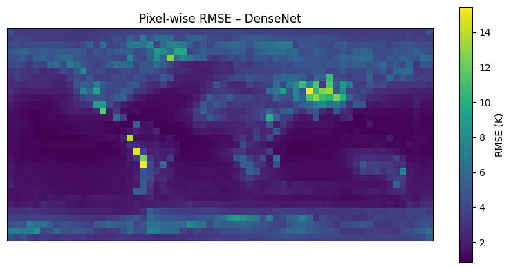

```python
pixelwise_rmse_densenet = np.sqrt(np.mean((y_pred_densenet - y_test) ** 2, axis=0))[..., 0]

plt.figure(figsize=(8, 4))
plt.imshow(pixelwise_rmse_densenet, origin='lower')
plt.colorbar(label='RMSE (K)')
plt.title("Pixel-wise RMSE – DenseNet")
plt.xticks([])
plt.yticks([])
plt.tight_layout()
plt.show()
```

The DenseNet-based model achieves the best overall performance, with lower RMSE values across almost all regions. Compared to the simple and complex CNNs, DenseNet benefits from:

- Dense connections, which improve feature reuse and gradient flow,
- Better spatial generalization, especially in tropical and dynamically active areas.

The pixel-wise RMSE map shows lower error concentration and better spatial consistency, indicating that the model captures local and global atmospheric patterns more effectively.

**Ejercicio 11** (1.5 puntos): Para terminar la práctica vamos a entrenar una arquitectura del tipo U-Net (como la vista en clase). Para ello primero vamos a modificar los datos de entrada y salida del modelo, ya que, aunque es posible, la U-Net fue diseñada en un principio para procesar imágenes cuadradas con un número de pixels proporcional a una potencia de 2. Para ello transformaremos tanto los predictores como el predictando de la siguente forma:

```python
x_data_unet, y_data_unet = x_data[:, :, :32, :], y_data[:, :, :32, :]
```

```python
print(f'X_unet shape: {x_data_unet.shape} | Y_unet shape: {y_data_unet.shape}')
```

```
X_unet shape: (14610, 32, 32, 6) | Y_unet shape: (14610, 32, 32, 1)
```

De esta forma nos centramos en el dominio que cubre América con un número de pixeles en la latitud y la longitud de $2^5=32$:

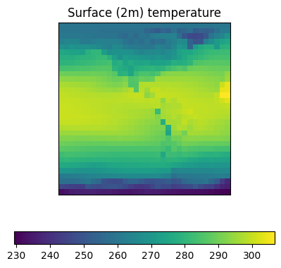

```python
plot_mean_subplots(data=y_data_unet, variable_dims=predictand_vars, figsize=(4, 4))
```

Recuerda que antes de entrenar el modelo es necesario volver a dividir en train y test y normalizar los datos. Podeis reutilizar el código de ejercicios anteriores

```python
# Split index (80% train)
split_idx = int(0.8 * x_data_unet.shape[0])

# Chronological split
x_train_unet = x_data_unet[:split_idx]
x_test_unet = x_data_unet[split_idx:]
y_train_unet = y_data_unet[:split_idx]
y_test_unet = y_data_unet[split_idx:]

# Min-max normalization per variable (axis: time, lat, lon)
x_min_unet = np.min(x_train_unet, axis=(0, 1, 2))
x_max_unet = np.max(x_train_unet, axis=(0, 1, 2))

x_train_unet_norm = (x_train_unet - x_min_unet) / (x_max_unet - x_min_unet)
x_test_unet_norm = (x_test_unet - x_min_unet) / (x_max_unet - x_min_unet)
```

Diseña y entrena una U-Net. En este caso el número de canales de entrada y salida no es el mismo, ten en cuenta esto. Se valorán de forma positiva variaciones con respecto a la presentada en clase. Entrena y evalua el modelo.

```python
from tensorflow.keras import Input, Model
from tensorflow.keras.layers import Conv2D, MaxPooling2D, UpSampling2D, Concatenate, Dropout, BatchNormalization, ReLU

def conv_block(x, filters, dropout=False):
    x = Conv2D(filters, (3, 3), padding='same')(x)
    x = BatchNormalization()(x)
    x = ReLU()(x)
    if dropout:
        x = Dropout(0.2)(x)
    x = Conv2D(filters, (3, 3), padding='same')(x)
    x = BatchNormalization()(x)
    x = ReLU()(x)
    return x

def build_unet(input_shape):
    inputs = Input(shape=input_shape)

    # Encoder
    c1 = conv_block(inputs, 32)
    p1 = MaxPooling2D((2, 2))(c1)

    c2 = conv_block(p1, 64)
    p2 = MaxPooling2D((2, 2))(c2)

    # Bottleneck
    c3 = conv_block(p2, 128, dropout=True)

    # Decoder
    u4 = UpSampling2D((2, 2))(c3)
    u4 = Concatenate()([u4, c2])
    c4 = conv_block(u4, 64)

    u5 = UpSampling2D((2, 2))(c4)
    u5 = Concatenate()([u5, c1])
    c5 = conv_block(u5, 32)

    outputs = Conv2D(1, (1, 1), activation='linear', padding='same')(c5)

    return Model(inputs, outputs)

# Create and compile model
unet_model = build_unet(input_shape=(32, 32, 6))
unet_model.compile(optimizer='adam', loss='mse', metrics=['mae'])
unet_model.summary()
```

```
Model: "functional_4"
```

```
┏━━━━━━━━━━━━━━━━━━━━━┳━━━━━━━━━━━━━━━━━━━┳━━━━━━━━━━━━┳━━━━━━━━━━━━━━━━━━━┓
┃ Layer (type)        ┃ Output Shape      ┃    Param # ┃ Connected to      ┃
┡━━━━━━━━━━━━━━━━━━━━━╇━━━━━━━━━━━━━━━━━━━╇━━━━━━━━━━━━╇━━━━━━━━━━━━━━━━━━━┩
│ input_layer_4       │ (None, 32, 32, 6) │          0 │ -                 │
│ (InputLayer)        │                   │            │                   │
├─────────────────────┼───────────────────┼────────────┼───────────────────┤
│ conv2d_16 (Conv2D)  │ (None, 32, 32,    │      1,760 │ input_layer_4[0]… │
│                     │ 32)               │            │                   │
├─────────────────────┼───────────────────┼────────────┼───────────────────┤
│ batch_normalizatio… │ (None, 32, 32,    │        128 │ conv2d_16[0][0]   │
│ (BatchNormalizatio… │ 32)               │            │                   │
├─────────────────────┼───────────────────┼────────────┼───────────────────┤
│ re_lu_6 (ReLU)      │ (None, 32, 32,    │          0 │ batch_normalizat… │
│                     │ 32)               │            │                   │
├─────────────────────┼───────────────────┼────────────┼───────────────────┤
│ conv2d_17 (Conv2D)  │ (None, 32, 32,    │      9,248 │ re_lu_6[0][0]     │
│                     │ 32)               │            │                   │
├─────────────────────┼───────────────────┼────────────┼───────────────────┤
│ batch_normalizatio… │ (None, 32, 32,    │        128 │ conv2d_17[0][0]   │
│ (BatchNormalizatio… │ 32)               │            │                   │
├─────────────────────┼───────────────────┼────────────┼───────────────────┤
│ re_lu_7 (ReLU)      │ (None, 32, 32,    │          0 │ batch_normalizat… │
│                     │ 32)               │            │                   │
├─────────────────────┼───────────────────┼────────────┼───────────────────┤
│ max_pooling2d       │ (None, 16, 16,    │          0 │ re_lu_7[0][0]     │
│ (MaxPooling2D)      │ 32)               │            │                   │
├─────────────────────┼───────────────────┼────────────┼───────────────────┤
│ conv2d_18 (Conv2D)  │ (None, 16, 16,    │     18,496 │ max_pooling2d[0]… │
│                     │ 64)               │            │                   │
├─────────────────────┼───────────────────┼────────────┼───────────────────┤
│ batch_normalizatio… │ (None, 16, 16,    │        256 │ conv2d_18[0][0]   │
│ (BatchNormalizatio… │ 64)               │            │                   │
├─────────────────────┼───────────────────┼────────────┼───────────────────┤
│ re_lu_8 (ReLU)      │ (None, 16, 16,    │          0 │ batch_normalizat… │
│                     │ 64)               │            │                   │
├─────────────────────┼───────────────────┼────────────┼───────────────────┤
│ conv2d_19 (Conv2D)  │ (None, 16, 16,    │     36,928 │ re_lu_8[0][0]     │
│                     │ 64)               │            │                   │
├─────────────────────┼───────────────────┼────────────┼───────────────────┤
│ batch_normalizatio… │ (None, 16, 16,    │        256 │ conv2d_19[0][0]   │
```

[output cut: 59 more lines]

```
├─────────────────────┼───────────────────┼────────────┼───────────────────┤
│ re_lu_14 (ReLU)     │ (None, 32, 32,    │          0 │ batch_normalizat… │
│                     │ 32)               │            │                   │
├─────────────────────┼───────────────────┼────────────┼───────────────────┤
│ conv2d_25 (Conv2D)  │ (None, 32, 32,    │      9,248 │ re_lu_14[0][0]    │
│                     │ 32)               │            │                   │
├─────────────────────┼───────────────────┼────────────┼───────────────────┤
│ batch_normalizatio… │ (None, 32, 32,    │        128 │ conv2d_25[0][0]   │
│ (BatchNormalizatio… │ 32)               │            │                   │
├─────────────────────┼───────────────────┼────────────┼───────────────────┤
│ re_lu_15 (ReLU)     │ (None, 32, 32,    │          0 │ batch_normalizat… │
│                     │ 32)               │            │                   │
├─────────────────────┼───────────────────┼────────────┼───────────────────┤
│ conv2d_26 (Conv2D)  │ (None, 32, 32, 1) │         33 │ re_lu_15[0][0]    │
└─────────────────────┴───────────────────┴────────────┴───────────────────┘
```

```
 Total params: 474,977 (1.81 MB)
```

```
 Trainable params: 473,697 (1.81 MB)
```

```
 Non-trainable params: 1,280 (5.00 KB)
```

```python
history_unet = unet_model.fit(
    x_train_unet_norm, y_train_unet,
    epochs=15,
    batch_size=32,
    validation_split=0.1,
    verbose=1
)
```

```
329/329 ━━━━━━━━━━━━━━━━━━━━ 40s 115ms/step - loss: 75887.5703 - mae: 274.9803 - val_loss: 70287.6172 - val_mae: 264.8315
329/329 ━━━━━━━━━━━━━━━━━━━━ 38s 116ms/step - loss: 67739.7656 - mae: 259.9460 - val_loss: 57778.4922 - val_mae: 240.0087
329/329 ━━━━━━━━━━━━━━━━━━━━ 42s 129ms/step - loss: 54579.2812 - mae: 232.9672 - val_loss: 43271.1289 - val_mae: 206.4747
329/329 ━━━━━━━━━━━━━━━━━━━━ 43s 132ms/step - loss: 39963.4297 - mae: 197.5121 - val_loss: 30018.0469 - val_mae: 168.7625
329/329 ━━━━━━━━━━━━━━━━━━━━ 44s 133ms/step - loss: 27153.0098 - mae: 158.6503 - val_loss: 19941.4785 - val_mae: 132.3822
329/329 ━━━━━━━━━━━━━━━━━━━━ 44s 135ms/step - loss: 12443.8057 - mae: 107.3200 - val_loss: 6583.5640 - val_mae: 78.6051
329/329 ━━━━━━━━━━━━━━━━━━━━ 48s 147ms/step - loss: 4249.3076 - mae: 62.0316 - val_loss: 1799.6801 - val_mae: 39.9050
329/329 ━━━━━━━━━━━━━━━━━━━━ 51s 155ms/step - loss: 1281.3527 - mae: 32.8738 - val_loss: 502.0006 - val_mae: 20.7589
329/329 ━━━━━━━━━━━━━━━━━━━━ 50s 153ms/step - loss: 314.3859 - mae: 15.5381 - val_loss: 103.1799 - val_mae: 9.0144
329/329 ━━━━━━━━━━━━━━━━━━━━ 50s 153ms/step - loss: 66.5437 - mae: 6.7795 - val_loss: 27.2238 - val_mae: 4.5803
329/329 ━━━━━━━━━━━━━━━━━━━━ 52s 158ms/step - loss: 16.1644 - mae: 3.1242 - val_loss: 14.0105 - val_mae: 2.7556
329/329 ━━━━━━━━━━━━━━━━━━━━ 52s 159ms/step - loss: 8.3839 - mae: 2.0826 - val_loss: 10.6424 - val_mae: 2.4560
329/329 ━━━━━━━━━━━━━━━━━━━━ 53s 162ms/step - loss: 6.9727 - mae: 1.8555 - val_loss: 8.3690 - val_mae: 1.9902
329/329 ━━━━━━━━━━━━━━━━━━━━ 54s 165ms/step - loss: 6.4315 - mae: 1.7758 - val_loss: 7.3700 - val_mae: 1.9122
329/329 ━━━━━━━━━━━━━━━━━━━━ 55s 167ms/step - loss: 5.8367 - mae: 1.6853 - val_loss: 7.6340 - val_mae: 1.8944
```

```python
# Predict using U-Net
y_pred_unet = unet_model.predict(x_test_unet_norm)

# Global metrics
rmse_unet = np.sqrt(mean_squared_error(y_test_unet.flatten(), y_pred_unet.flatten()))
mae_unet = mean_absolute_error(y_test_unet.flatten(), y_pred_unet.flatten())
print(f"U-Net – RMSE: {rmse_unet:.2f}, MAE: {mae_unet:.2f}")
```

```
92/92 ━━━━━━━━━━━━━━━━━━━━ 3s 29ms/step
U-Net – RMSE: 2.78, MAE: 1.90
```

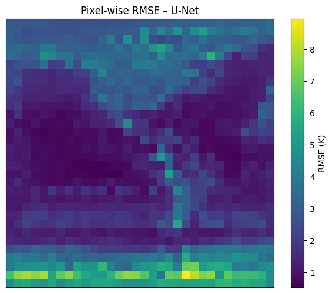

```python
pixelwise_rmse_unet = np.sqrt(np.mean((y_pred_unet - y_test_unet) ** 2, axis=0))[..., 0]

plt.figure(figsize=(6, 5))
plt.imshow(pixelwise_rmse_unet, origin='lower')
plt.colorbar(label='RMSE (K)')
plt.title("Pixel-wise RMSE – U-Net")
plt.xticks([])
plt.yticks([])
plt.tight_layout()
plt.show()
```

```python
import pandas as pd

# Recap
results_final = {
    "Model": ["Simple CNN", "Complex CNN", "DenseNet", "U-Net"],
    "RMSE":  [6.689, 3.801, 3.587, rmse_unet],
    "MAE":   [4.906, 2.696, 2.465, mae_unet]
}

df_final = pd.DataFrame(results_final)
display(df_final)
```

|  | Model | RMSE | MAE |
| --- | --- | --- | --- |
| 0 | Simple CNN | 6.689000 | 4.90600 |
| 1 | Complex CNN | 3.801000 | 2.69600 |
| 2 | DenseNet | 3.587000 | 2.46500 |
| 3 | U-Net | 2.782464 | 1.89753 |

The table summarizes the global RMSE and MAE for all the models implemented in this project. Each architectural improvement led to better performance:

- The Simple CNN provides a baseline.
- The Complex CNN improves results through depth and regularization.
- The DenseNet enhances feature reuse via dense residual connections.
- Finally, the U-Net achieves the lowest errors overall, especially on a reduced but more focused spatial domain.

These results highlight the importance of model design in spatiotemporal prediction problems.

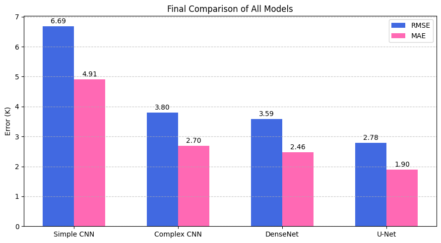

```python
models = ["Simple CNN", "Complex CNN", "DenseNet", "U-Net"]
rmse_values = [6.689, 3.801, 3.587, 2.782]
mae_values = [4.906, 2.696, 2.465, 1.898]

x = np.arange(len(models))  # posizioni asse x
width = 0.3  # larghezza delle barre

fig, ax = plt.subplots(figsize=(9, 5))

bars1 = ax.bar(x - width/2, rmse_values, width, label='RMSE', color='royalblue')
bars2 = ax.bar(x + width/2, mae_values, width, label='MAE', color='hotpink')

ax.set_ylabel('Error (K)')
ax.set_title('Final Comparison of All Models')
ax.set_xticks(x)
ax.set_xticklabels(models)
ax.legend()
ax.grid(axis='y', linestyle='--', alpha=0.7)

for bar in bars1 + bars2:
    height = bar.get_height()
    ax.text(bar.get_x() + bar.get_width()/2, height + 0.05, f'{height:.2f}', ha='center', va='bottom')

plt.tight_layout()
plt.show()
```

### Referencias

**[1]** Rasp, S., Dueben, P. D., Scher, S., Weyn, J. A., Mouatadid, S., & Thuerey, N. (2020). WeatherBench: a benchmark data set for data‐driven weather forecasting. Journal of Advances in Modeling Earth Systems, 12(11), e2020MS002203.

**[2]** Rasp, S., Hoyer, S., Merose, A., Langmore, I., Battaglia, P., Russell, T., ... & Sha, F. (2024). WeatherBench 2: A benchmark for the next generation of data‐driven global weather models. Journal of Advances in Modeling Earth Systems, 16(6), e2023MS004019.

**[3]** Huang, G., Liu, Z., Van Der Maaten, L., & Weinberger, K. Q. (2017). Densely connected convolutional networks. In Proceedings of the IEEE conference on computer vision and pattern recognition (pp. 4700-4708).

**[4]** Prince, S. J. (2023). *Understanding deep learning*. MIT press.